# Boruta Feature Selection and Neural Networks for Detecting Adulteration in Ground Coffee: Raw Spectra

Author

Derick Malavi

## Introduction

Coffee adulteration, such as blending premium Arabica with lower-cost Robusta, undermines quality and authenticity, posing significant challenges for consumers, producers, and regulators. High-dimensional spectroscopic data provides valuable insights for detecting such fraud, but the sheer number of variables requires effective feature selection techniques to isolate the most relevant wavelengths.

This study leverages the Boruta algorithm, a robust feature selection method that identifies all relevant variables by iteratively comparing the importance of original features with randomized counterparts using a Random Forest framework. Unlike traditional methods, Boruta not only ensures the inclusion of critical spectral features but also prevents the selection of irrelevant or redundant variables, which is essential for improving model interpretability and accuracy.

By integrating Boruta with machine learning models, this study demonstrates an efficient and reliable approach to classify pure and adulterated coffee samples. The results highlight the potential of this method for detecting and quantifying coffee adulteration, ultimately supporting efforts to maintain product quality and authenticity in the coffee industry.

## Setup and Load Packages

```r
# Load libraries
warning = FALSE
  suppressWarnings(suppressMessages({
  library(caret)
  library(GA)
  library(Boruta)
  library(ggplot2)
  library(dplyr)
  library(readxl)
  library(readr)
  library(pls)
  library(ggthemes)
  library(janitor)
  library(class)
  library(MLmetrics)
  library(MLeval)
  library(themis)
  library(ROSE)
  library(parallel)
  library(doParallel)
  library(foreach)
  library(pheatmap)
  library(mdatools)
  library(nnet)
  library(DMwR)
  library(e1071)
  library(knitr)
  library(pROC)
  library(gridExtra)
  library(FactoMineR)
  library(doSNOW)
  library(MASS)
  library(factoextra)
  library(kernlab)}))
```

## Prepare Data

```r
# Load data: raw spectra

hsi_raw <- read.csv("instant_coffee_raw.csv")

# Ensure we have the same number of dimensions and the range of our columns/covariates
dim(hsi_raw)
```

```
[1] 1476  229
```

```r
# Check a few column names
col_check <- colnames(hsi_raw[,c(1:6)])
col_check
```

```
[1] "sample_name"  "binary_class" "three_class"  "cal_val"      "perc_adulter"
[6] "X935.609985"
```

```r
# The spectral values start from column # 6-------> 229

# Convert the class to a factor
hsi_raw$binary_class <- as.factor(hsi_raw$binary_class)
```

## Get the X and y variables

```r
X <- hsi_raw[,c(6:229)]
y <- hsi_raw[,2]

class(y) #Ensure y (target variable) is a factor for classification
```

```
[1] "factor"
```

## Visualize X

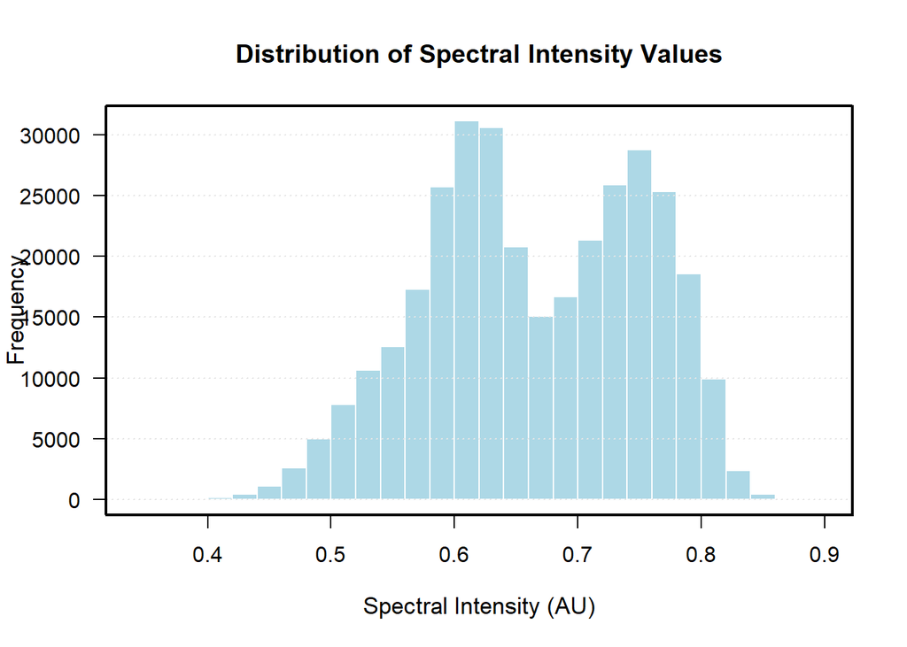

```r
# Create histogram of spectral intensities with improved formatting
hist(as.matrix(X),
     col = "lightblue",
     border = "white",
     main = "Distribution of Spectral Intensity Values",
     xlab = "Spectral Intensity (AU)",
     ylab = "Frequency",
     las = 1,
     cex.main = 1.2,
     cex.lab = 1.1,
     breaks = 30)

# Add grid lines
grid(nx = NA, ny = NULL, col = "gray90", lty = "dotted")

# Add box around plot
box(lwd = 2)
```